# 5. Introducción al deep learning (i)

## Técnicas Avanzadas de Predicción en Negocios

### Juan D. Montoro-Pons | 2025/26

# Conceptos

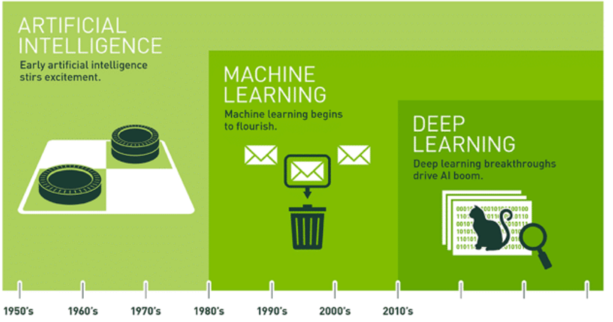

Fuente: L.N. Zúñiga-Morales

## Redes Neuronales Artificiales

- Las redes neuronales artificiales (RNA) son **aproximadores universales de funciones** (permiten aproximar cualquier función continua).
- Las RNA se estructuran en nodos, cada uno de los cuales realiza un cálculo sobre una entrada, y capas, que son colecciones de nodos que tienen acceso a las mismas entradas.
- Algunas variantes (o arquitecturas)
  - **Perceptrón** de una sola capa o multicapa (o **red neuronal feedforward**). Estructura más común; útil en datos de corte transversal.
  - **Redes neuronales recurrentes**: diseñadas para problemas en los que los datos son secuenciales, como el caso de las series temporales o en determinadas representaciones vectoriales de texto.
  - **Redes neuronales convolucionales**: diseñadas para trabajar con datos en forma de malla en las que se observa una fuerte dependencia espacial en los datos (p.e., una imagen representada como una matriz de pixels en 2D dónde unidades adyacentes suelen tener colores similares).
- Pueden aplicarse al aprendizaje supervisado (por ejemplo, regresión y clasificación), aprendizaje no supervisado y aprendizaje por refuerzo.

> Las RNA forman la base de los modelos de aprendizaje profundo.

# El perceptrón o red neuronal *feed-forward*

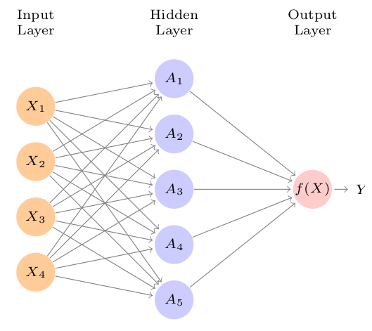

Fuente: Introduction to Statistical Learning

## Estructura

Estructura de una red neuronal feedforward con una capa oculta:

- **Capa de entrada**: conjunto de neuronas $X_1,X_2\ldots X_p$ (predictores o características de entrada). Cada entrada alimenta a $K$ neuronas en una capa oculta
- **Capa oculta**: conjunto de $K$ neuronas que transforman las entradas. Cada neurona produce un valor o activación $A_k$ que es una transformación de las entradas
  $$A_k=h_k(X)=g(w_{k0}+\sum^p_{j=1}w_{kj}X_j)$$
  donde $g(z)$ es una función de activación no lineal.
- Las activaciones producidas en la capa oculta alimentan la **capa de salida**. En el caso de un problema de regresión (la salida $Y \in \mathbb{R}$)
  $$f(X)=\beta_0+\sum_k \beta_k A_k$$
  (Un modelo de regresión lineal de $Y$ sobre las $K$ activaciones)

## Perceptón: interpretación

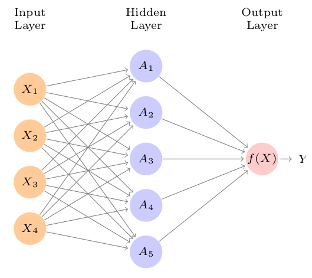

**Interpretación de una red neuronal feedforward con una capa oculta**

- Las características $X_1\ldots X_4$ alimentan la capa oculta
- La red neuronal deriva cinco nuevas características al calcular $K=5$ combinaciones lineales diferentes de $X$
- Estas se introducen en una función de activación no lineal $g(\cdot)$ para producir $A_k$
- El modelo final es lineal en estas variables derivadas $A_k$ (si el problema es de regresión) o no lineal (para problemas de clasificación)

La no linealidad en $g$ es esencial: sin ella $f(X)$ se reduciría a un modelo lineal.

## Perceptrón de una sola capa: el modelo paramétrico

- Una red neuronal toma un vector de $p$ variables $X=(X_1,X_2,\ldots X_p)$ para construir una función no lineal $f(X)$ que predice la respuesta $Y$
- El modelo de red neuronal resultante con una capa oculta para regresión puede resumirse como
  $$f(X)=\beta_0+\sum_k \beta_k A_k = \beta_0+\sum_k \beta_k h_k(X)= \beta_0+\sum_k \beta_k\, g(w_{k0}+\sum^p_{j=1}w_{kj}X_j)$$
- Los parámetros $\beta_0 \ldots \beta_K, w_{10}\ldots w_{Kp}$ se estiman a partir de los datos.

> Las RNA son modelos paramétricos. ¿Cuantos parámetros (o pesos) se deben estimar en un perceptrón con 4 inputs, una capa oculta con 5 activaciones y una salida $Y\in \mathbb{R}$).

## Funciones de activación: nodo de salida

Sea $z$ la combinación lineal en la capa de salida, es decir, $z=\beta_0+\sum_k\beta_k A_k$. Entonces:

1. Lineal: opción utilizada en el nodo de salida si la respuesta es real (problemas de regresión)
   $$f(z)=z$$
2. Soft-max: utilizada en el nodo de salida para transformar $k$ salidas reales con $k$ probabilidades que sumen la unidad (problemas de clasificación)
   $$f(z_i)=\frac{\exp(z_i)}{\sum_{j=1}^k\exp(z_j) }$$
3. Signo:
   $$f(z)=\mathrm{signo}(z)$$

## Funciones de activación: capa(s) oculta(s)

Sea $z$ la entrada al nodo en la capa $k$. Entonces:

1. Sigmoide:
   $$g(z)=\frac{e^z}{1+e^z}=\frac{1}{1+e^{-z}}$$
2. Tangente hiperbólica:
   $$g(z)=\frac{e^{2z}-1}{e^{2z}+1}$$
3. Unidad lineal rectificada (ReLU):
   $$g(z)=
   \begin{cases}
   0, & z < 0 \\
   z, & \textrm{en otro caso}
   \end{cases}$$

> El uso de funciones de activación no lineales es fundamental para generar aproximaciones de alta calidad

## Ejemplo: el perceptron de una sola capa

- Entrenamiento de un perceptrón
- Escalado de los predictores

```python
import pandas as pd
from sklearn.model_selection import train_test_split
url = "https://juandmontoro.github.io/bigDataEco/data/housing.csv"
data = pd.read_csv(url)
var_num = data.drop(columns='median_house_value').select_dtypes(exclude='object').columns
data = data.dropna()
data = pd.get_dummies(data,dtype=int)
X = data.drop(columns=['median_house_value'])
y = data['median_house_value'] /1000 # expresamos el precio en miles de USD
X_train,X_test,y_train,y_test = train_test_split(X,y,test_size=0.3,random_state=42)

from sklearn.neural_network import MLPRegressor

mlp = MLPRegressor(hidden_layer_sizes=(200),
                    activation='relu',        # rectified linear unit
                    early_stopping=True,
                    validation_fraction=0.1,
                    n_iter_no_change=10,
                    batch_size = 20,       # minilotes  (sgd)
                    max_iter = 200,        # número de epochs (sgd)
                    learning_rate='constant',
                    learning_rate_init=0.001
                    )

mlp.fit(X_train,y_train);

print('R2  entrenamiento:', f"{mlp.score(X_train,y_train):.4f}", '\nR2 test:',
f"{mlp.score(X_test,y_test):.4f}")
```

```
R2  entrenamiento: 0.6889
R2 test: 0.6834
```

```python
from sklearn.preprocessing import StandardScaler
from sklearn.pipeline import make_pipeline
from sklearn.compose import ColumnTransformer

trf = ColumnTransformer([('numericas',StandardScaler(),var_num)],
                        remainder='passthrough')

pipe = make_pipeline(trf,mlp)

pipe.fit(X_train,y_train);

print('R2  entrenamiento:', f"{pipe.score(X_train,y_train):.4f}", '\nR2 test:',
f"{pipe.score(X_test,y_test):.4f}")
```

```
R2  entrenamiento: 0.7227
R2 test: 0.7130
```

# Aprendizaje profundo

## Redes neuronales profundas

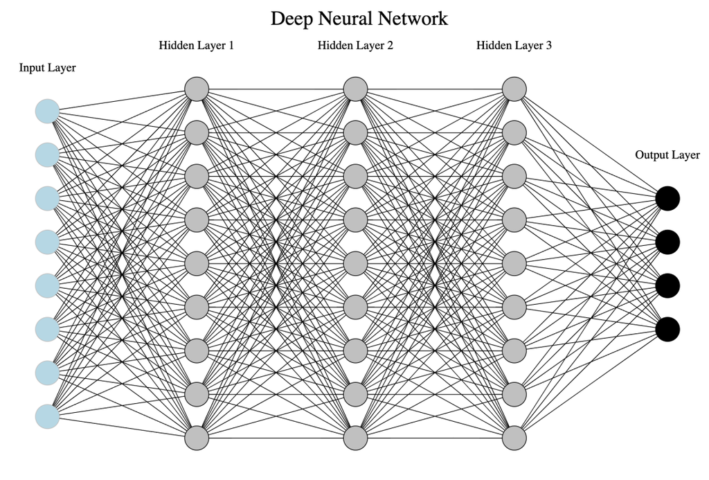

## El perceptrón multicapa

- La arquitectura específica de las redes neuronales multicapa se denomina **redes feed-forward** porque las capas sucesivas se alimentan unas a otras en dirección hacia adelante, desde la entrada hasta la salida.
- Por defecto se asume que todos los nodos de una capa están conectados a los de la siguiente capa (**redes densas**).
- La arquitectura de la red neuronal queda casi completamente definida una vez que se especifican:
  - El **número de capas**.
  - El **número de nodos** en cada capa.

**Principio de ingeniería jerárquica de características**

- Cada capa construye características progresivamente más complejas, relevantes para el problema predictivo.
- Este principio se conoce como **ingeniería jerárquica de características**.

## Ancho vs. profundidad

> Equivalencia parcial: Un MLP con una sola capa oculta y suficiente ancho puede aproximar cualquier función continua (*Teorema del Aproximador Universal*).

La flexibilidad del modelo depende del número de neuronas (ancho) y capas (profundidad) en una red neuronal. Más neuronas o capas aumentan la flexibilidad, similar a añadir regresores en modelos lineales de alta dimensión.

Pero esta equivalencia es parcial al menos por tres motivos:

1. Eficiencia: Para representar ciertas funciones, una red profunda necesita muchas menos neuronas que una red poco profunda y ancha.
2. Composición jerárquica: Las redes profundas aprenden composiciones de funciones $(f(f(f(...))))$; una red ancha no captura tan bien esas estructuras.
3. Generalización: Las redes más profundas tienden a generalizar mejor (aunque su entrenamiento es más complejo), mientras que las muy anchas tienden a memorizar (cada nodo se especializa en un subconjunto de los datos en ausencia de regularización suficiente).

## Ejemplo: perceptrón multicapa

```python
mlp = MLPRegressor(hidden_layer_sizes=(50,50,50),
                    activation='relu',
                    early_stopping=True,
                    validation_fraction=0.1,
                    n_iter_no_change=10,
                    batch_size = 20,       # minilotes  (sgd)
                    max_iter = 200,        # número de epochs (sgd)
                    learning_rate='constant',
                    learning_rate_init=0.001,
                    random_state=42
                    )
pipe = make_pipeline(trf,mlp)
pipe.fit(X_train,y_train);

print('R2  entrenamiento:', f"{pipe.score(X_train,y_train):.4f}", '\nR2 test:',
f"{pipe.score(X_test,y_test):.4f}")
```

```
R2  entrenamiento: 0.7620
R2 test: 0.7381
```

## Intuición: profundidad en redes neuronales

En arquitecturas profundas *feed-forward*, las transformaciones sucesivas de las entradas generan representaciones cada vez más sofisticadas de las entradas.

- Cada capa introduce una transformación sobre transformaciones previas
- La composición repetida de funciones no lineales simples puede crear funciones no lineales complejas.
- Esta composición crea representaciones jerárquicas: de detectar patrones simples en los datos pasamos a patrones de patrones
- Cada capa aprende patrones más refinados a partir de los patrones aprendidos en capas anteriores.
- La riqueza de la función global *capturada* por la red aumenta con la profundidad.

## Ejemplo: identificación de dígitos

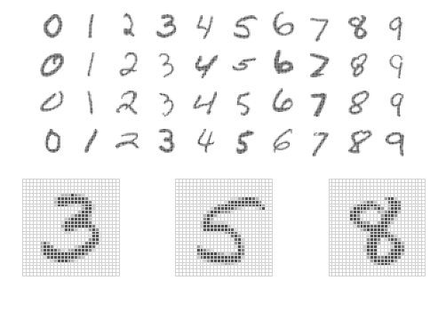

Fuente: Introduction to Statistical Learning

## Ejemplo: identificación de dígitos

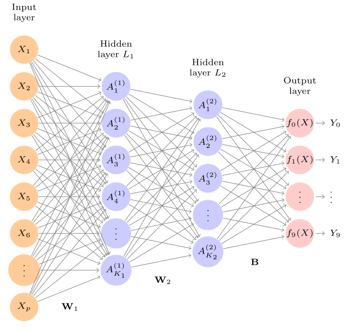

Fuente: Introduction to Statistical Learning

## Ejemplo: identificación de dígitos

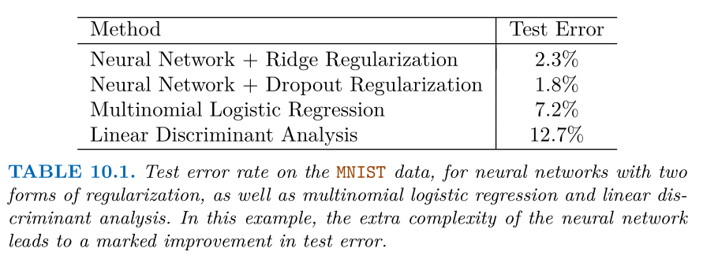

Fuente: Introduction to Statistical Learning